# Conjugate Families

July 10, 2025  
Thursday

## Introduction: Gamma-Poisson Model

- Recall the Beta-Binomial model,
  - $y \sim \text{Bin}(n, \pi)$ (data distribution)
  - $\pi \sim \text{Beta}(\alpha, \beta)$ (prior distribution)
  - $\pi|y \sim \text{Beta}(\alpha+y, \beta+n-y)$ (posterior distribution)
- The Beta-Binomial model is from a *conjugate family* (i.e., the posterior is from the same model family as the prior).
- Now, we will learn about the Gamma-Poisson, another conjugate family.

## Example Set Up

- Suppose we are now interested in modeling the number of spam calls we receive.
  - This means that we are modeling the rate, $\lambda$.
- We take a guess and say that the value of $\lambda$ that is most likely is around 5,
  - … but reasonably ranges between 2 and 7 calls per day.
- Why can’t we use the Beta distribution as our prior distribution?
  - $\lambda$ is the mean of a count $\to$ $\lambda \in \mathbb{R}^+$ $\to$ $\lambda$ is not limited to $[0, 1]$ $\to$ broken assumption for Beta distribution.
- Why can’t we use the binomial distribution as our data distribution?
  - $Y_i$ is a count $\to$ $Y_i \in \mathbb{N}^+$ $\to$ $Y_i$ is not limited to $\{0, 1\}$ $\to$ broken assumption for Binomial distribution.

## Poisson Data Model

- We will use the Poisson distribution to model the number of spam calls

$$Y \in \{0, 1, 2, ...\}$$

- $Y$ is the number of independent events that occur in a fixed amount of time or space.
- $\lambda > 0$ is the rate at which these events occur.
- Mathematically,

$$Y | \lambda \sim \text{Pois}(\lambda),$$

- with pmf,

$$f(y|\lambda) = \frac{\lambda^y e^{-\lambda}}{y!}, \ \ \ y \in \{0,1, 2, ... \}$$

## Gamma Prior

- If $\lambda$ is a continuous random variable that can take on any positive value ($\lambda > 0$), then the variability may be modeled with the Gamma distribution with
  - shape hyperparameter $s>0$
  - rate hyperparameter $r>0$.
- Thus,

$$\lambda \sim \text{Gamma}(s, r)$$

- and the Gamma pdf is given by

$$f(\lambda) = \frac{r^s}{\Gamma(s)} \lambda^{s-1} e^{-r\lambda}$$

## Gamma Prior: Shapes

- Let’s explore the shape of the Gamma:

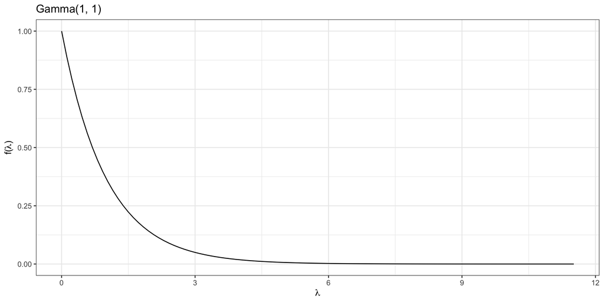

```r
plot_gamma(1, 1) + theme_bw() + ggtitle("Gamma(1, 1)")
```

## Gamma Prior: Shapes

- Let’s explore the shape of the Gamma:

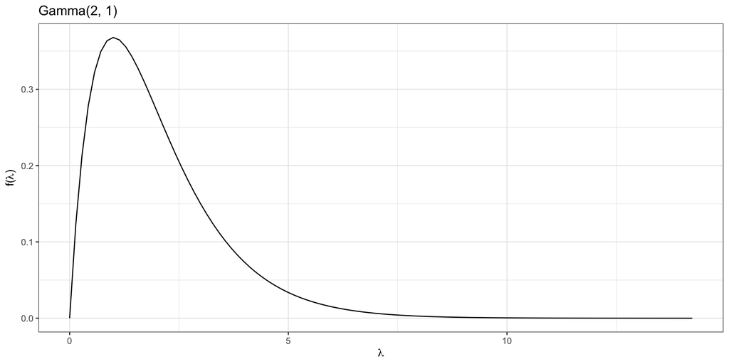

```r
plot_gamma(2, 1) + theme_bw() + ggtitle("Gamma(2, 1)")
```

## Gamma Prior: Shapes

- Let’s explore the shape of the Gamma:

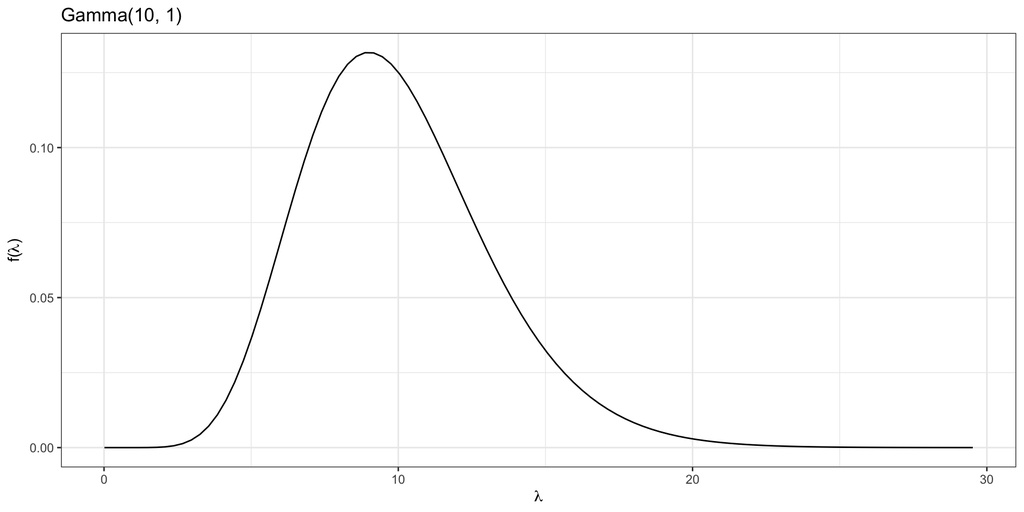

```r
plot_gamma(10, 1) + theme_bw() + ggtitle("Gamma(10, 1)")
```

## Gamma Prior: Shapes

- Let’s explore the shape of the Gamma:

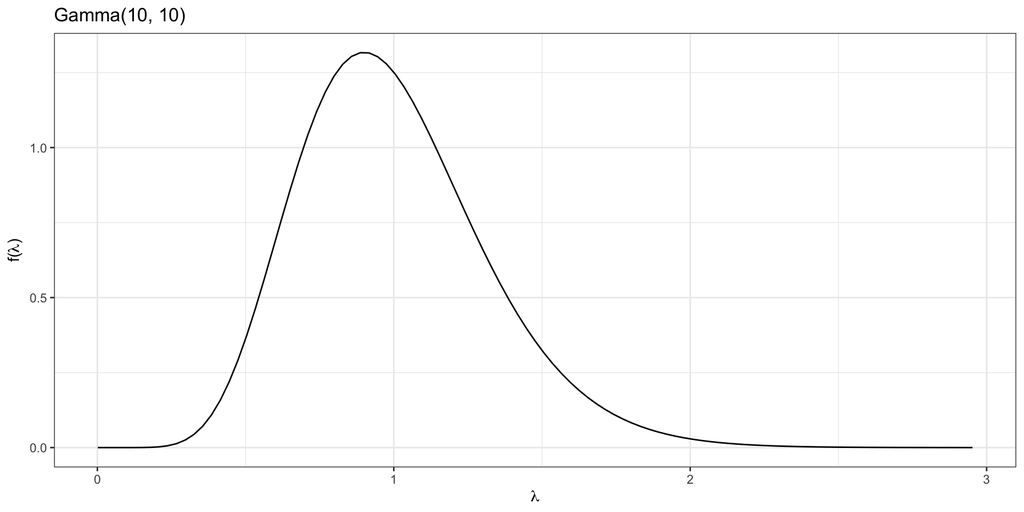

```r
plot_gamma(10, 10) + theme_bw() + ggtitle("Gamma(10, 10)")
```

## Gamma Prior: Shapes

- What happens when we increase the $\alpha$ parameter?

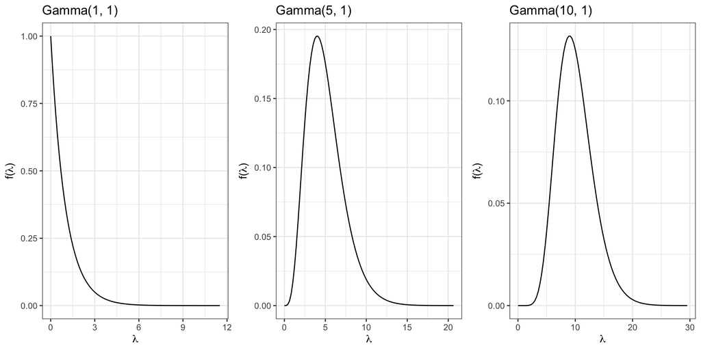

## Gamma Prior: Shapes

- What happens when we increase the $\beta$ parameter?

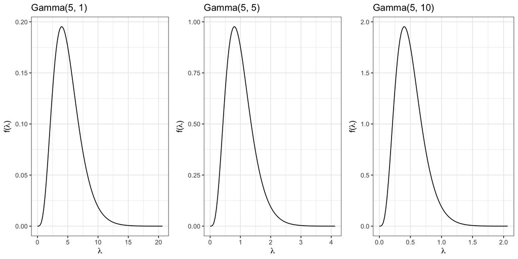

## Gamma Prior: Shapes

- Putting these on the same scale,

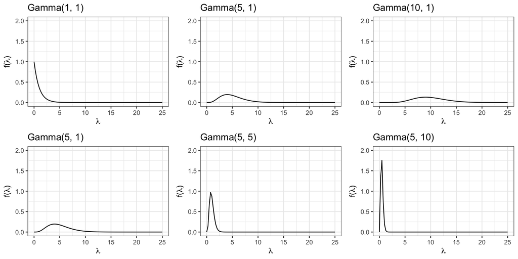

## Tuning the Gamma Prior

- Let’s now tune our prior.
- We are assuming $\lambda \approx 5$, somewhere between 2 and 7.
- We know the mean of the gamma distribution,

$$E(\lambda) = \frac{s}{r} \approx 5 \to 5r \approx s$$

- Your turn! Use the `plot_gamma()` function to figure out what value of $s$ and $r$ we need.

## Tuning the Gamma Prior

- Looking at different values:

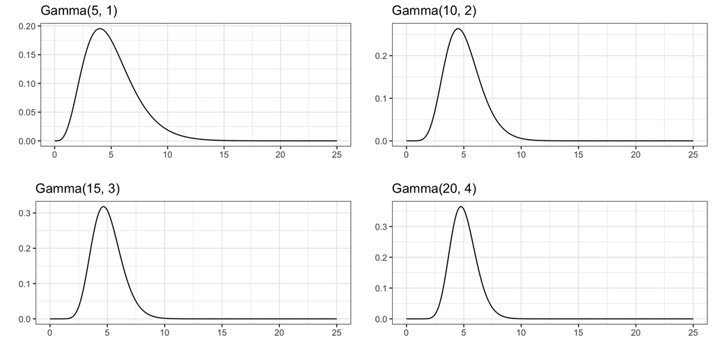

## Poisson Data Model

- We will be taking samples from different days.
  - We assume that the daily number of calls may differ from day to day. On each day $i$,

$$Y_i|\lambda \sim \text{Pois}(\lambda)$$

- This has a unique pmf for each day ($i$),

$$f(y_i|\lambda) = \frac{\lambda^{y_i} e^{-\lambda}}{y_i!}$$

- But really, we are interested in the *joint* information in our sample of $n$ observations.
  - The joint pmf gives us this information.

## Poisson Data Model

- The joint pmf for the Poisson,

$$\begin{align*}
f\left(\overset{\to}{y_i}|\lambda\right) &= \prod_{i=1}^n f(y_i|\lambda) \\
&= f(y_1|\lambda) \times f(y_2|\lambda) \times ... \times f(y_n|\lambda) \\
&= \frac{\lambda^{y_1}e^{-\lambda}}{y_1!} \times \frac{\lambda^{y_2}e^{-\lambda}}{y_2!} \times ... \times \frac{\lambda^{y_n}e^{-\lambda}}{y_n!} \\
&= \frac{\left( \lambda^{y_1} \lambda^{y_2} \cdot \cdot \cdot \ \lambda^{y_n} \right) \left( e^{-\lambda} e^{-\lambda} \cdot \cdot \cdot e^{-\lambda}\right)}{y_1! y_2! \cdot \cdot \cdot y_n!} \\
&= \frac{\lambda^{\sum y_i}e^{-n\lambda}}{\prod_{i=1}^n y_i !}
\end{align*}$$

## Poisson Data Model

- If the joint pmf for the Poisson is

$$f\left(\overset{\to}{y_i}|\lambda\right) = \frac{\lambda^{\sum y_i}e^{-n\lambda}}{\prod_{i=1}^n y_i !}$$

- then the likelihood function for $\lambda > 0$ is

$$\begin{align*}
L\left(\lambda|\overset{\to}{y_i}\right) &= \frac{\lambda^{\sum y_i}e^{-n\lambda}}{\prod_{i=1}^n y_i !} \\
& \propto \lambda^{\sum y_i} e^{-n\lambda}
\end{align*}$$

- Pease see page 102 in the textbook for full derivations.

## Gamma-Poisson Conjugacy

- Let $\lambda > 0$ be an unknown *rate* parameter and $(Y_1, Y_2, ... , Y_n)$ be an independent sample from the Poisson distribution.
- The Gamma-Poisson Bayesian model is as follows:

$$\begin{align*}
Y_i | \lambda &\overset{ind}\sim \text{Pois}(\lambda) \\
\lambda &\sim \text{Gamma}(s, r) \\
\lambda | \overset{\to}y &\sim \text{Gamma}\left( s + \sum y_i, r + n \right)
\end{align*}$$

- The proof can be seen in section 5.2.4 of the textbook.

## Gamma-Poisson Conjugacy

- Suppose we use Gamma(10, 2) as the prior for $\lambda$, the daily rate of calls.
- On four separate days in the second week of August (i.e., independent days), we received $\overset{\to}y = (6, 2, 2, 1)$ calls.
- We will use the `plot_poisson_likelihood()` function:

```r
plot_poisson_likelihood(y = c(6, 2, 2, 1), lambda_upper_bound = 10)
```

- Notes:
  - `lambda_upper_bound` limits the $x$ axis – recall that $\lambda \in (0, \infty)$!
  - `lambda_upper_bound`’s default value is 10.

## Gamma-Poisson Conjugacy

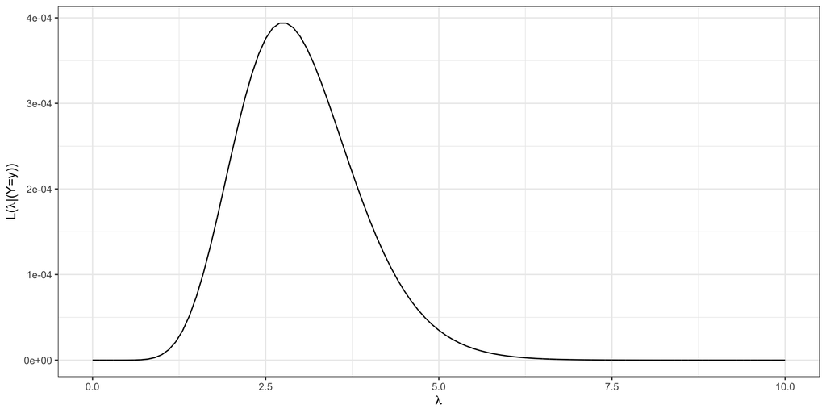

- We can see that the average is around 2.75.

```r
mean(c(6, 2, 2, 1))
```

```
[1] 2.75
```

## Gamma-Poisson Conjugacy

- We know our prior distribution is Gamma(10, 2) and the data distribution is Poi(2.75).
- Thus, the posterior is as follows,

$$\begin{align*}
\lambda | \overset{\to}y &\sim \text{Gamma}\left( s + \sum y_i, r + n \right) \\
&\sim \text{Gamma}\left(10 + 11, 2 + 4 \right) \\
&\sim \text{Gamma}\left(21, 6 \right)
\end{align*}$$

## The Gamma Posterior Model

- Looking at just the prior and the data distributions,

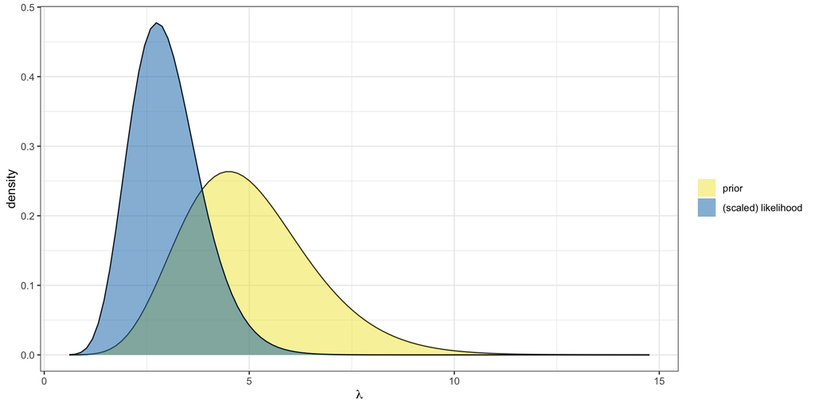

- The prior expects more spam calls than what we observed.

## The Gamma Posterior Model

- Now including the posterior,

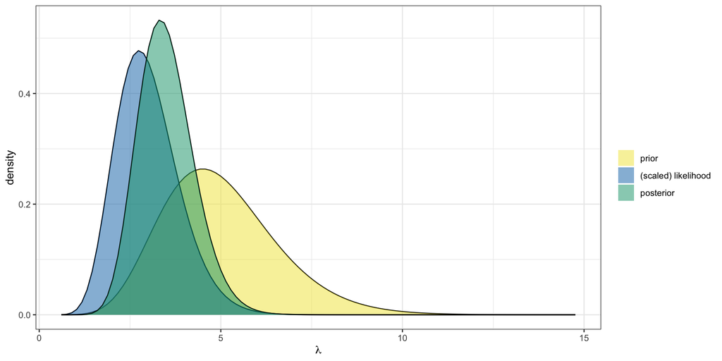

- The shape of the posterior has a Gamma($s$, $r$) model.
  - The shape and rate parameters ($s$ and $r$) have been *updated*.

## The Gamma Posterior Model

- The `plot_gamma_poisson()` function:

```r
plot_gamma_poisson(shape = prior_s, rate = prior_r,
                   sum_y = sum_of_obs, n = sample_size,
                   posterior = TRUE or FALSE) +
  theme_bw()
```

## The Gamma Posterior Model

- Your turn! What is different if we had used one of the other priors?
- Recall, we considered
  - Gamma(5, 1)
  - Gamma(10, 2)
  - Gamma(15, 3)
  - Gamma(20, 4)

## The Gamma Posterior Model

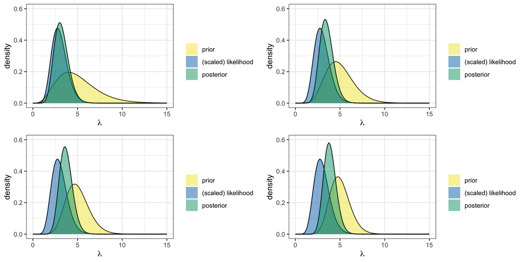

## Wrap Up: Gamma-Poisson Model

- We have built the Gamma-Poisson model for $\lambda$, an unknown rate.

$$\begin{equation*}
\begin{aligned}
Y|\lambda &\sim \text{Poi}(\lambda) \\
\lambda &\sim \text{Gamma}(s, r) &
\end{aligned}
\Rightarrow
\begin{aligned}
&& \lambda | y &\sim \text{Gamma}(s + \sum y_i, r + n) \\
\end{aligned}
\end{equation*}$$

- The prior model, $f(\lambda)$, is given by Gamma($s, r$).
- The data model, $f(Y|\lambda)$, is given by Poi($\lambda$).
- The posterior model is a Gamma distribution with updated parameters $s+\sum y_i$ and $r + n$.